# Sta-395 - First Day Debrief

### An Example Solution

```r
## Read data
data <- read.csv("https://remiller1450.github.io/data/GradAdm.csv")

## Notice the problem
prop.table(table(data$sex, data$admit), margin = 1) # 23.9% of M but only 19.3% of F are admitted
```

```
##
##             N         Y
##   F 0.8066997 0.1933003
##   M 0.7610337 0.2389663
```

```r
## Is random chance a possible explanation? (considering this year a representative sample of the school more broadly - other years, etc.)
chisq.test(table(data$sex, data$admit))  # No, the difference is very unlikely to be due to chance
```

```
##
##  Pearson's Chi-squared test with Yates' continuity correction
##
## data:  table(data$sex, data$admit)
## X-squared = 62.725, df = 1, p-value = 2.377e-15
```

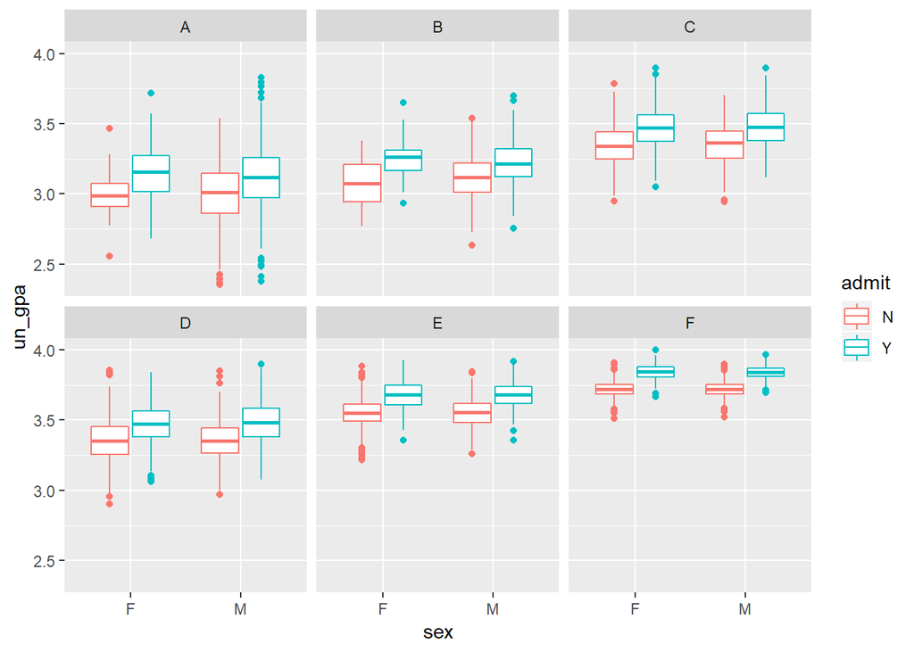

```r
## But could the other variables be confounding this relationship?

## Notice GPA is a red herring - it doesn't confound the relationship b/w sex and admit
library(ggplot2)
ggplot(data, aes(y = un_gpa, x = sex, col = admit)) + geom_boxplot() + facet_wrap(~ dept)
```

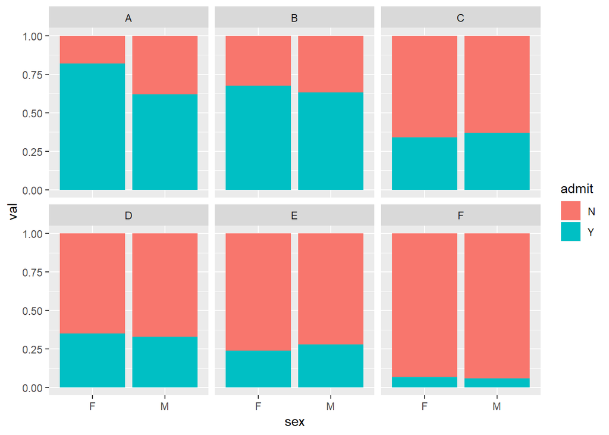

```r
## Dept might be a confounding variable

## Process data for stacked barcharts
library(dplyr)
counts <- group_by(data, sex, admit, dept) %>% summarize(val = n())

## Graphs of choice --->>>
ggplot(counts, aes(fill=admit, y=val, x=sex)) +
    geom_bar(position="fill", stat="identity") + facet_wrap(~ dept)
```

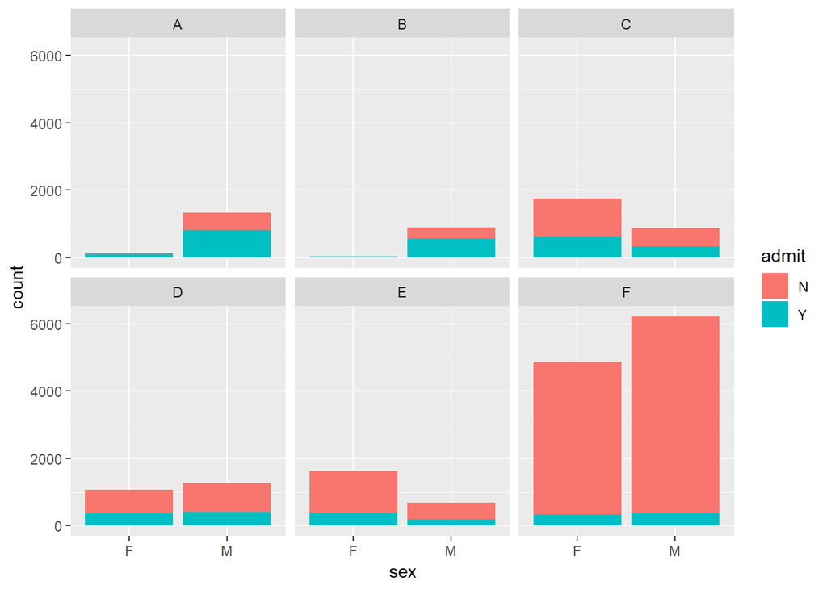

```r
## Supporting graph explaining the paradox
ggplot(data, aes(fill=admit, x=sex)) +
    geom_bar(position = "stack") + facet_wrap(~ dept)
```

> Although there is a difference in the overall admissions rates of male and female grad school applicants, this difference is explained by the different departments males and females are applying to. Within each department, males and females are admitted at roughly equal rates. The overall difference is explained by the applicants to the least selective departments (A and B) being nearly exclusively male.

### Simpson’s Paradox

“Simpson’s Paradox is a phenomenon in probability and statistics, in which a trend appears in several different groups of data but disappears or reverses when these groups are combined. This result is often encountered in social-science and medical-science statistics and is particularly problematic when frequency data is unduly given causal interpretations. The paradox can be resolved when causal relations are appropriately addressed in the statistical modeling. Simpson’s paradox has been used as an exemplar to illustrate to the non-specialist or public audience the kind of misleading results mis-applied statistics can generate.” - [Source](https://en.wikipedia.org/wiki/Simpson%27s_paradox)

### Takeaway

Imagine you didn’t have the variable `dept` in the data you collected. The conclusions of your analysis wouldn’t reflect reality. As a statistician and data scientist it is *your job* (not your collaborators!) to be aware of this possibility. You need to learn enough background information about the data and topic you are studying in order to be able to anticipate these variables.